# Red Wine Quality Analysis

It might be a better way to use normalised Sulphates data, or discuss the relationship by grouping the Sulphates.

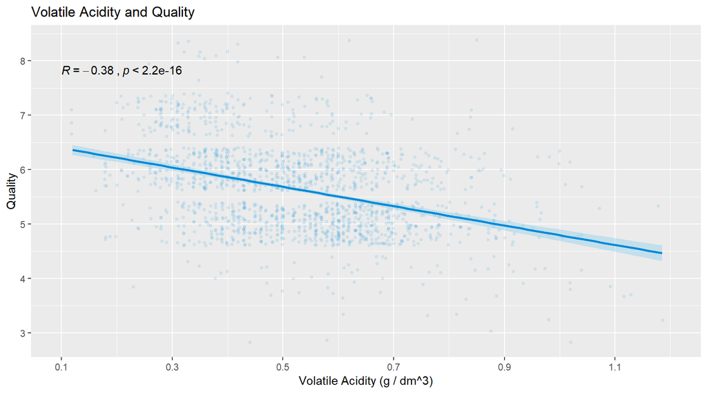

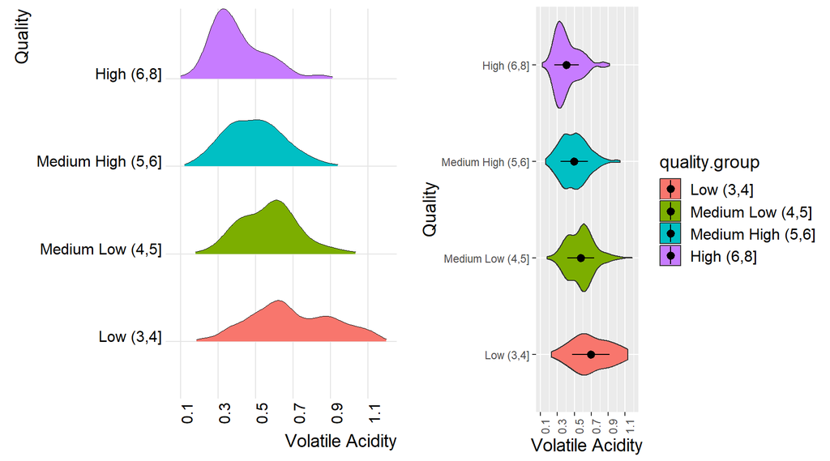

Volatile Acidity and Quality

From scatter plot, it can be seen that the quality score decreases, when Volatile Acidity increase, but the trend is not obvious.

In the ridgeline and violine plot, the x of the distributions moves to the left, with the change of the quality groups. The shape of the 4 groups are similar.

The spearman coefficient is -0.38 (weak negative correlation), indicating a same result as what we got from the plots.

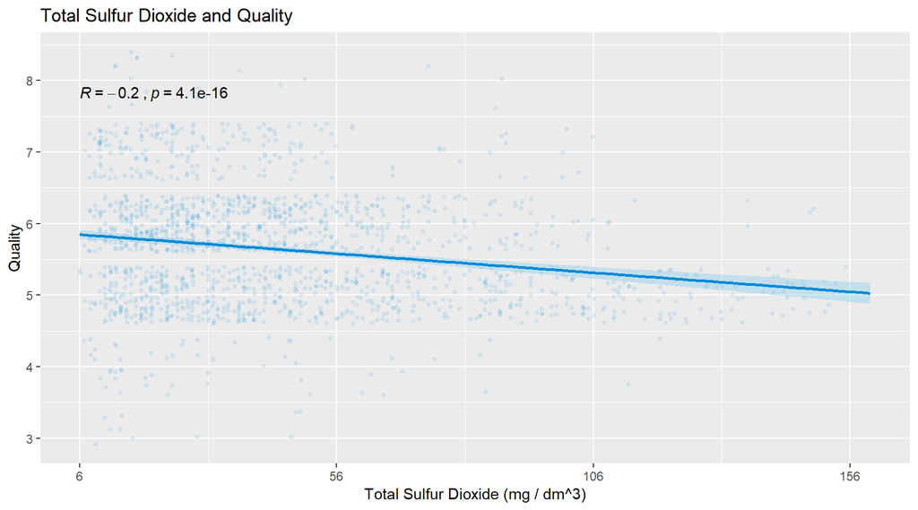

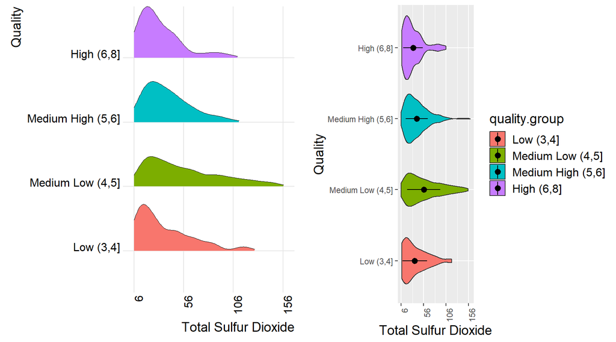

From the plots above, we can find that there are 3 chemicals correlated with quality:

- Volatile Acidity: negative
- Sulphates: positive
- Alcohol: positive

The following section summarises all of the Spearman Correlation Coefficients mentioned above.

### Spearman Correlation Coefficient: Quality vs Chemicals

| chemicals | r |
| --- | --- |
| Alcohol | 0.4785317 |
| Volatile Acidity | -0.3806465 |
| Sulphates | 0.3770602 |
| Citric Acid | 0.2134809 |
| Total Sulfur Dioxide | -0.1967351 |
| Chlorides | -0.1899223 |
| Density | -0.1770741 |
| Fixed Acidity | 0.1140837 |
| Free Sulfur Dioxide | -0.0569006 |
| pH Value | -0.0436719 |
| Residual Sugar | 0.0320482 |

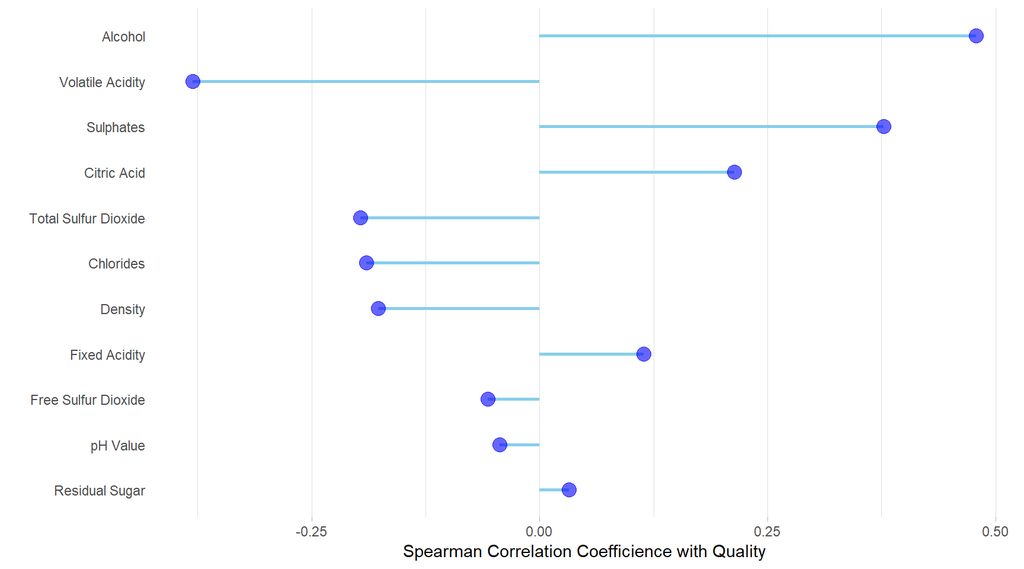

- Alcohol, Volatile Acidity and Sulphates are correlated with quality.
- Other chemicals are not correlated with quality.

## Bivariate - Chemicals

After analysing the relationship between the quality score and chemicals, the relationship between 11 chemicals will be explored in this section.

### Correlation Matrix

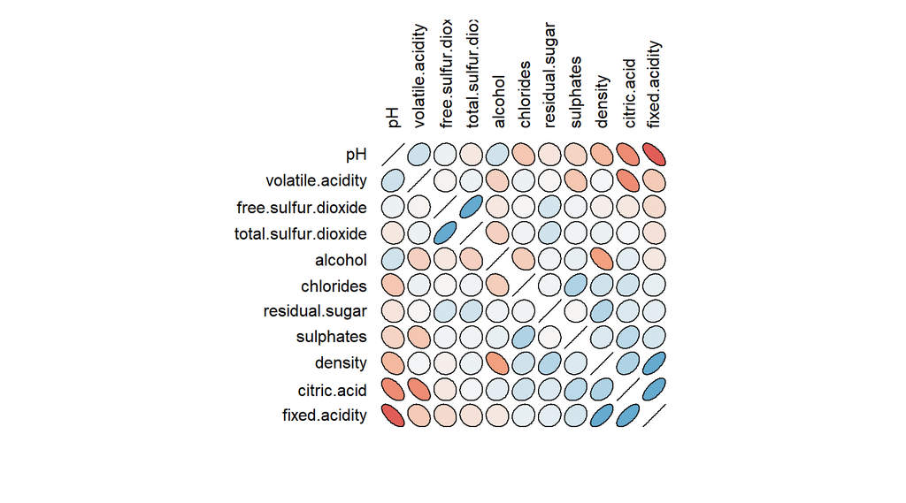

From the correlation matrix, it could be seen that there some chemicals are highly correlated with others:

- pH v.s Fixed Acidity
- pH v.s. Citric Aciity
- Citric Acid v.s. Fixed Acidity
- Citric Acidity v.s. Volatile Acidity
- Density v.s. Fixed Acidity
- Free Sulfur Dioxide v.s. Total Sulfur Dioxide

Besides, the three chemicals that are correlated with quality - Alcohol, Volatile Acidity and Sulphates, are not correlate with each other.

The Pearson correlation coefficients between chemicals is shown in the following table.

### Pearson Correlation Coefficient between Chemicals

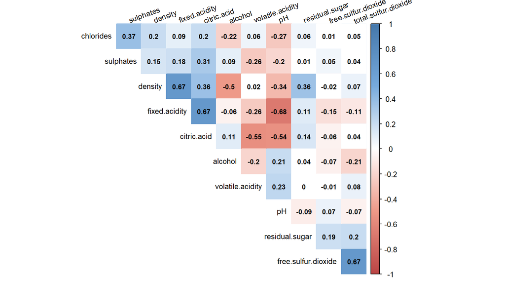

Pearson Correlation Coefficient of Highly Correlated Chemicals:

- pH v.s Fixed Acidity: -0.68
- pH v.s. Citric Aciity: -0.54
- Citric Acid v.s. Fixed Acidity: 0.67
- Citric Acid v.s. Volatile Acidity: -0.55
- Density v.s. Fixed Acidity: 0.67
- Free Sulfur Dioxide v.s. Total Sulfur Dioxide: 0.67

The relationship between these chemicals are shown in the following plots.

### Moderately / Highly Correlated Chemicals

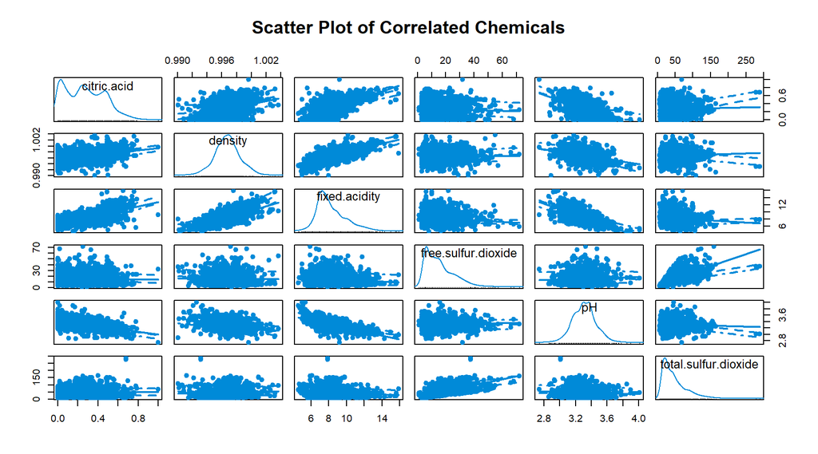

## Multivariate - Chemicals

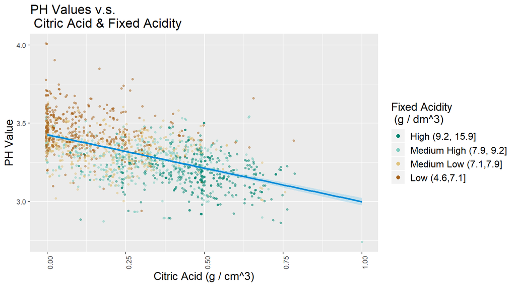

From the plot, we can easily see the trends:

- Citric Acid and pH values are negatively correlated.
- Fixed acidity and pH values are negatively correlated.
- Fixed acidity and Citric Acid are positively correlated.

## Multivariate - Quality v.s. Chemicals

3 chemicals are correlated with quality:

- Volatile Acidity: negative
- Sulphates: positive
- Alcohol: positive

From the correlation matrix above, it can be found that these 3 chemicals are not correlated with each other. Thus, they independently affect quality scores.

### Quality, Alcohol and Volatile Acidity

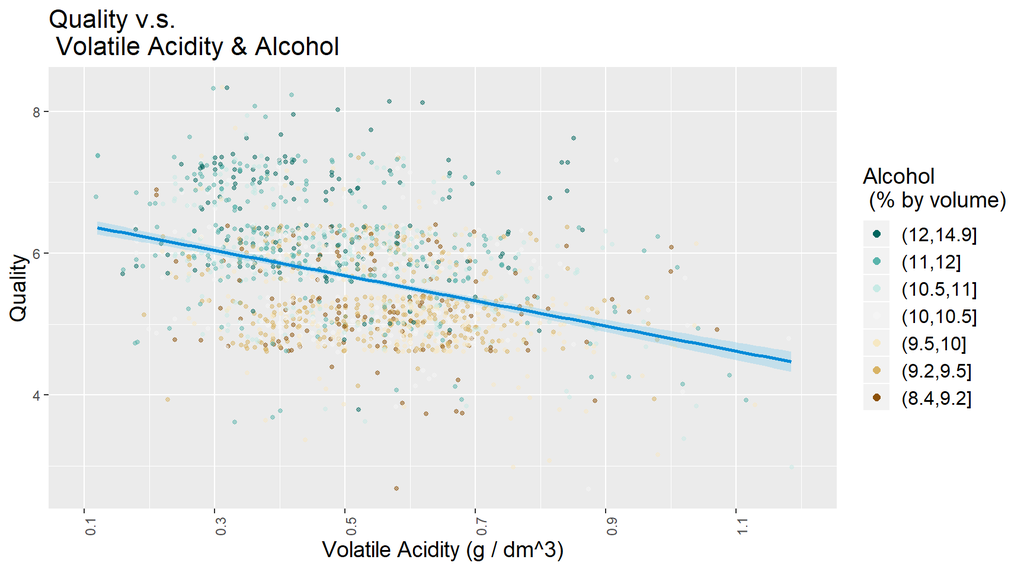

- Alcohol and quality are positively correlated.
- Volatile acidity and quality are negatively correlated.

### Quality, Alcohol and Sulphates

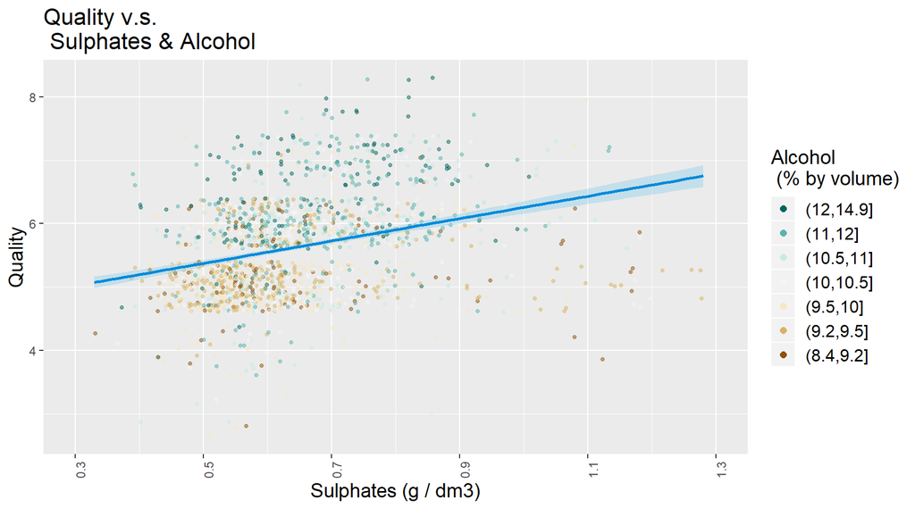

- Alcohol and quality are positively correlated.
- Sulphates and quality are positively correlated.

# Final Plots and Summary

## Quality, Alcohol and Volatile Acidity

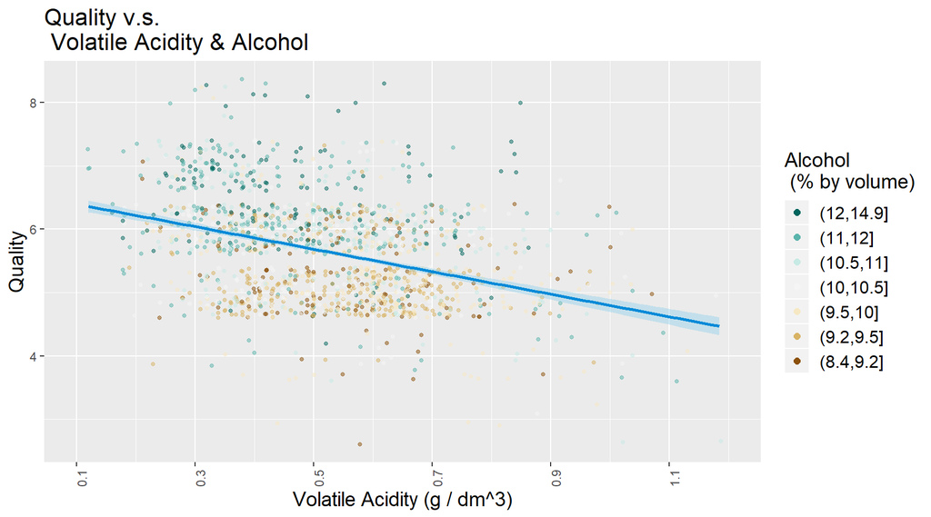

- Alcohol and quality are positively correlated.
- Volatile acidity and quality are negatively correlated.

## Quality, Alcohol and Sulphates

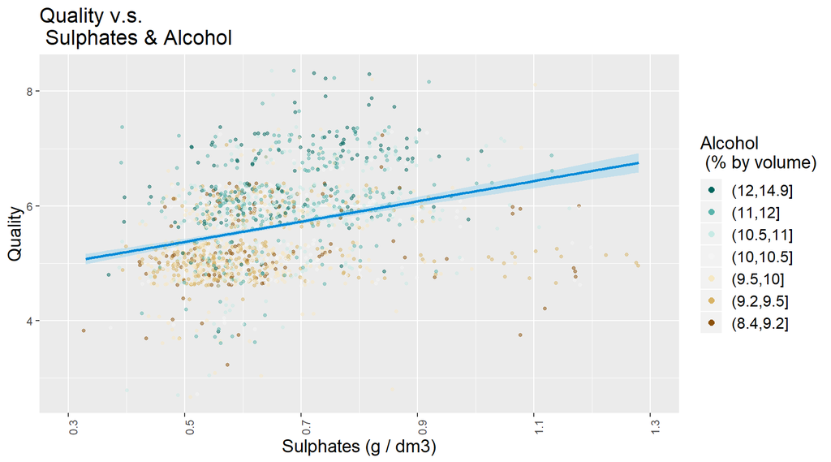

- Alcohol and quality are positively correlated.
- Sulphates and quality are positively correlated.

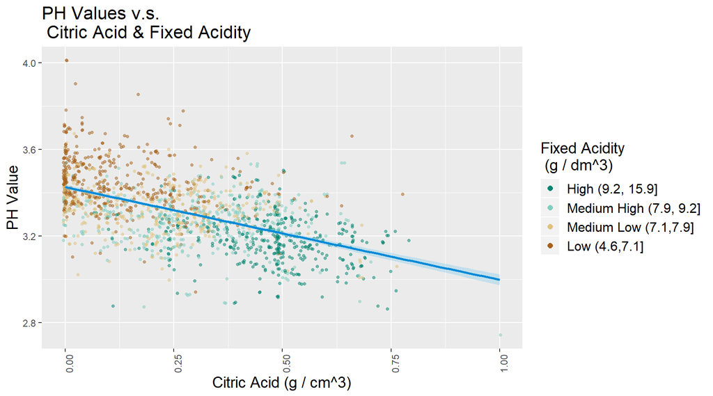

# Reflection

## Conclusion

3 out of 11 chemicals are moderately correlated with quality:

- Volatile Acidity (negatively),
- Sulphates (positively) and
- Alcohol (positively),

while others are not correlated.

Besides, these 3 chemicals are not correlated with each other. Thus, they can be used to predict the quality score.

## Limitation

There are some chemicals highly correlated with each other:

- pH and Fixed Acidity
- pH and. Citric Aciity
- Citric Acid and Fixed Acidity
- Citric Acidity and Volatile Acidity
- Density and Fixed Acidity
- Free Sulfur Dioxide and Total Sulfur Dioxide

To design a better experiment, it would be helpful to drop some of the highly correlated variables.

Besides, the quality scores are mainly between 5-6, and some are 7. It can be noticed that none of the wines were scored 0-2 and 9-10. Usually a 5-point scale would be better for scoring.

It might also be helpful to ask experts to score the acidity and sweetness after tasting (e.g 1-Not sweet at all ~ 5-Too sweet). Then we can compare the degree of real sweetness /sourness and the subjective feeling of it.

## Success and Improvement

I feel it is much more clear to separate the data and the plot function. The code structure is better after gathering data and put it into array-like storage.

I would try more kinds of plots and to add more details for the plots the next time (e.g. I tried to add a layer to show correlation coefficiency on the scatter plot, but I failed.)

[^1]: Information of the Original Data: P. Cortez, A. Cerdeira, F. Almeida, T. Matos and J. Reis. Modeling wine preferences by data mining from physicochemical properties. In Decision Support Systems, Elsevier, 47(4):547-553. ISSN: 0167-9236.